# Acitivty Prediction

Alex Chang

Saturday, November 22, 2014

The purpose of this report is to analyize data from accelerometers on the belt, forearm, arm, and dumbell of 6 participants to determine the manner of in which they did the excericse.

```r
myData <- read.csv("./data/training.csv")

# Loading librarys
library(corrplot);library(caret);library(rpart);
```

# Variable Selection

I start off by looking near zero variance covariates. And select the covariates that are both not near zero and not NA.

```r
nsv <- nearZeroVar(myData, saveMetrics=TRUE)
# exame the data
nsv
```

[output not shown]

[output cut: 106 more lines]

[output not shown]

```r
# Remove near zero variances
myData <- myData[,c(nsv$nzv==FALSE)]
# Remove variances that has NA
myData <- myData[,(colSums(is.na(myData))==0)]
# Remove covariaates X as it is completely unique and factor variables except classe (this is the predictor)
myData <- myData[,7:ncol(myData)]
```

# Split data into test set and validation set

```r
inTrain <- createDataPartition(y=myData$classe,p=0.7,list=FALSE)
training <- myData[inTrain,]; testing <- myData[-inTrain,]
```

# Correlation Analysis

```r
M <- abs(cor(training[,-53]))
diag(M) <- 0
cor <- which(M > 0.9, arr.ind=T)
```

# Training control

```r
ctrl <- trainControl(method = "repeatedcv", repeats = 5)
```

# Model Fitting using Tree

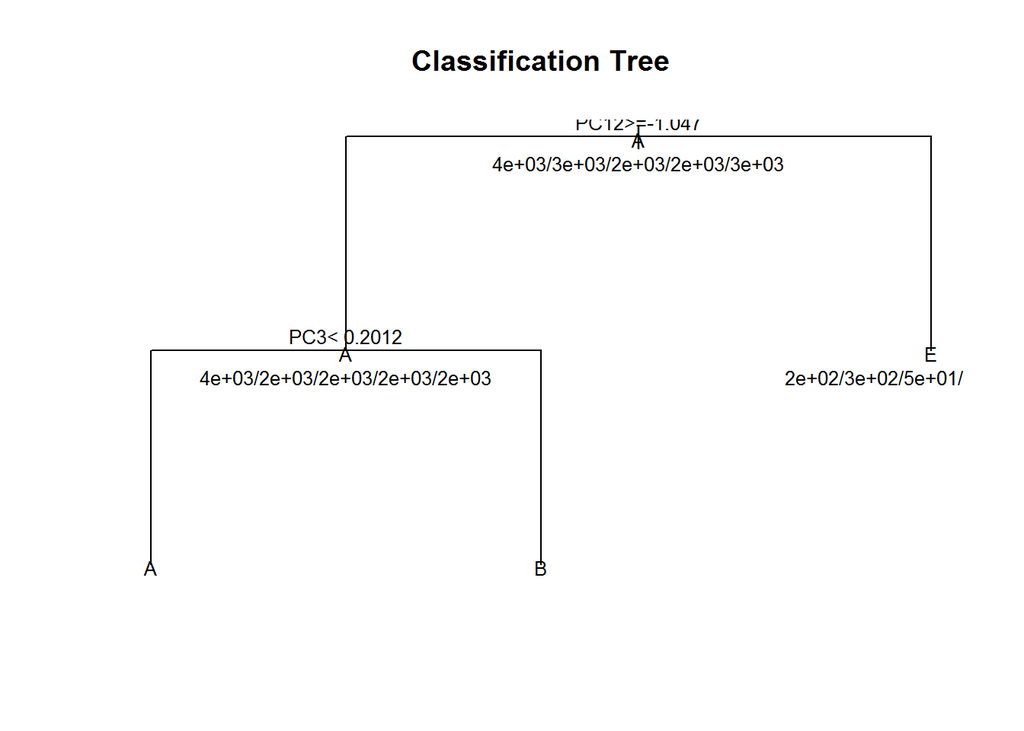

```r
modFitTree <- train(classe~.,method="rpart",preProcess="pca",data=training, trControl=ctrl)
plot (modFitTree$finalModel , uniform=TRUE , main="Classification Tree")
text(modFitTree$finalModel, use.n=TRUE, all=TRUE, cex=.8)
```

```r
modFitTree
```

```
## CART
##
## 13737 samples
##    52 predictor
##     5 classes: 'A', 'B', 'C', 'D', 'E'
##
## Pre-processing: principal component signal extraction, scaled, centered
## Resampling: Cross-Validated (10 fold, repeated 5 times)
##
## Summary of sample sizes: 12362, 12365, 12365, 12363, 12362, 12364, ...
##
## Resampling results across tuning parameters:
##
##   cp    Accuracy  Kappa  Accuracy SD  Kappa SD
##   0.03  0.4       0.1    3e-02        0.05
##   0.06  0.3       0.1    2e-02        0.04
##   0.12  0.3       0.0    3e-04        0.00
##
## Accuracy was used to select the optimal model using  the largest value.
## The final value used for the model was cp = 0.03377.
```

The first learning algorithm that I choose to use is tree.

# Predict the result using validation set

The validation against the testing set is shown below.

```r
predictions <- predict(modFitTree,testing)
confusionMatrix(predictions, testing$classe)
```

```
## Confusion Matrix and Statistics
##
##           Reference
## Prediction    A    B    C    D    E
##          A 1253  470  635  304  294
##          B  342  548  374  429  447
##          C    0    0    0    0    0
##          D    0    0    0    0    0
##          E   79  121   17  231  341
##
## Overall Statistics
##
##                Accuracy : 0.364
##                  95% CI : (0.352, 0.376)
##     No Information Rate : 0.284
##     P-Value [Acc > NIR] : <2e-16
##
##                   Kappa : 0.165
##  Mcnemar's Test P-Value : NA
##
## Statistics by Class:
##
##                      Class: A Class: B Class: C Class: D Class: E
## Sensitivity             0.749   0.4811    0.000    0.000   0.3152
## Specificity             0.596   0.6646    1.000    1.000   0.9067
## Pos Pred Value          0.424   0.2561      NaN      NaN   0.4322
## Neg Pred Value          0.856   0.8422    0.826    0.836   0.8546
## Prevalence              0.284   0.1935    0.174    0.164   0.1839
## Detection Rate          0.213   0.0931    0.000    0.000   0.0579
## Detection Prevalence    0.502   0.3636    0.000    0.000   0.1341
## Balanced Accuracy       0.672   0.5728    0.500    0.500   0.6109
```

# Conclusion

Based on the figure above, model has accuracy of roughly 40%. Therefore, I expect the error rate to be 60%.